# districts

Author

Olaf König

```r
# Data manipulation
library(tidyverse)
library(readr)
library(readxl)

# Data visualization
library(ggplot2)
library(tmap)

# Utility
library(here)
library(janitor)

# Custom theme for plots
theme_set(theme_minimal())

# Disable scientific notation
options(scipen = 999)
# # Re-enable scientific notation (default behavior)
# options(scipen = 0)
```

```r
# Define project paths
input_raw_dir <- here("input", "raw")
input_processed_dir <- here("input", "processed")
output_dir <- here("output")
```

## 1 Import des datasets

```r
# Import géométrie
library(sf)
library(mapview)
st_layers(file.path(input_processed_dir, "historisierte-administrative_grenzen_g1_2025-01-01_2056.gpkg"))
```

```
Driver: GPKG
Available layers:
             layer_name geometry_type features fields       crs_name
1      Lacs_G1_20250101 Multi Polygon       22     11 CH1903+ / LV95
2  Communes_G1_20250101 Multi Polygon     2137     25 CH1903+ / LV95
3 Districts_G1_20250101 Multi Polygon      143     19 CH1903+ / LV95
4   Cantons_G1_20250101 Multi Polygon       26     15 CH1903+ / LV95
5   Country_G1_20250101 Multi Polygon        4     14 CH1903+ / LV95
```

```r
sf_district <- read_sf(
  dsn = file.path(input_processed_dir, "historisierte-administrative_grenzen_g1_2025-01-01_2056.gpkg"),
  layer = "Districts_G1_20250101"
)
```

```r
# Import df issus de Excel
df_districts <- read.csv(file.path(input_processed_dir, "students_entries_24_25_districts.csv")) |>
  select(-X)

# Import PX 18-25 par districts
px_statpop_18_25_bezk <- read.csv(file.path(input_processed_dir, "px_statpop_18_25_bezk.csv")) |>
  filter(annee == 2024) |>
  select(BEZNR, sexe, value) |>
  pivot_wider(
    names_from = sexe,
    values_from = value
  ) |>
    rename(
      f_18_25 = Femme,
      h_18_25 = Homme,
      tot_18_25 = `Sexe - total`
    )
```

```r
# Création d'un fichier Districts SF

sf_districts_data <- sf_district |>
  select(
    BEZHISTID, BEZNR, BEZNAME, E_CNTR, N_CNTR
  ) |>
    left_join(
      df_districts, by = c("BEZHISTID" = "geocode_districts")
    ) |>
      left_join(px_statpop_18_25_bezk) |>
      mutate(
        tx_tot_18_25 = stu_et_total / tot_18_25 * 100,
        tx_h_18_25 = stu_et_h / h_18_25 * 100,
        tx_f_18_25 = stu_et_f / f_18_25 * 100
      )
```

## 2 0. Map

```r
tmap_mode("view")

tm_shape(sf_districts_data) +
  tm_polygons(
    col = "tx_tot_18_25",
    palette = "YlOrBr",
    style = "quantile", n = 5,
    title = "Étudiants / 100 habitants 18–25 ans"
  ) +
  tm_layout(
    frame = FALSE,
    legend.outside = TRUE,
    title = "Taux d'étudiants (18–25 ans) par district"
  )
```

[interactive chart not shown]

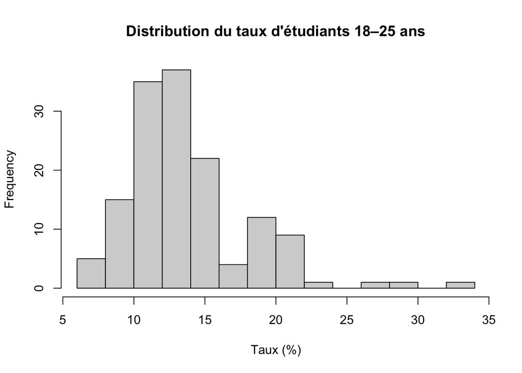

```r
hist(sf_districts_data$tx_tot_18_25, breaks = 10,
     main = "Distribution du taux d'étudiants 18–25 ans",
     xlab = "Taux (%)")
```

#### 2.0.1 DW Maps

https://app.datawrapper.de/tamedia/edit/VgHcv/visualize#refine

```r
id_canton <- tamMap::canton_CH()  |>
  select(
    order, iso2
  ) |>
    rename(
      geocode_cantons = order
    )
```

```r
sf_districts_data |>
  st_drop_geometry() |>
  DatawRappr::dw_data_to_chart("VgHcv")
```

#### 2.0.2 DW table

https://app.datawrapper.de/tamedia/edit/HAX27/upload

```r
sf_districts_data |>
  st_drop_geometry() |>
    left_join(id_canton) |>
  select(
    district, iso2, pct_f, tx_tot_18_25:tx_f_18_25
  ) |>
  DatawRappr::dw_data_to_chart("HAX27")
```

### Map Facet with percent of 18-25

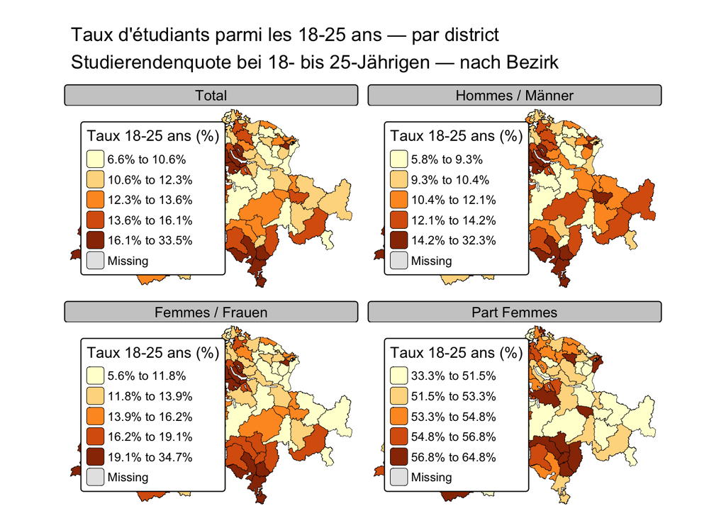

```r
library(tidyr)
tmap_mode("plot")

# Transformer en format long pour les facettes
sf_districts_long <- sf_districts_data %>%
  pivot_longer(
    cols = c(tx_tot_18_25, tx_h_18_25, tx_f_18_25, pct_f),
    names_to = "type",
    values_to = "taux"
  ) %>%
  mutate(
    type = factor(type,
      levels = c("tx_tot_18_25", "tx_h_18_25", "tx_f_18_25", "pct_f"),
      labels = c("Total", "Hommes / Männer", "Femmes / Frauen", "Part Femmes")
    )
  )

# Carte avec facettes
tm <- tm_shape(sf_districts_long) +
  tm_polygons(
    col = "taux",
    palette = "YlOrBr",
    style = "quantile",
    n = 5,
    border.col = "black",
    lwd = 0.5,
    colorNA = "grey90",
    title = "Taux 18-25 ans (%)",
    legend.format = list(suffix = "%", digits = 1)
  ) +
  tm_facets(
    by = "type",
    ncol = 2,
    free.scales = TRUE  # FALSE = même échelle pour toutes les facettes
  ) +
  tm_layout(
    frame = FALSE,
    legend.outside = TRUE,
    legend.title.size = 1.0,
    legend.text.size = 0.8,
    main.title = "Taux d'étudiants parmi les 18-25 ans — par district\nStudierendenquote bei 18- bis 25-Jährigen — nach Bezirk",
    main.title.size = 1.1
  )

tm
```

## 3 1. Quels districts ont le taux de “scolarisation” le plus élevé/faible ?

```r
# Top 10 et bottom 10
sf_districts_data %>%
  select(district, permille_total) %>%
  arrange(desc(permille_total)) %>%
  slice(c(1:10, (n()-9):n()))
```

```
Simple feature collection with 20 features and 2 fields
Geometry type: MULTIPOLYGON
Dimension:     XY
Bounding box:  xmin: 2485424 ymin: 1085239 xmax: 2811070 ymax: 1293269
Projected CRS: CH1903+ / LV95
# A tibble: 20 × 3
   district                             permille_total                      geom
   <chr>                                         <dbl>        <MULTIPOLYGON [m]>
 1 Meilen                                        25.6  (((2702758 1232905, 2702…
 2 De Lavaux-Oron                                24.6  (((2550860 1146955, 2549…
 3 De Nyon                                       24.4  (((2518657 1146471, 2518…
 4 De Morges                                     20.4  (((2530258 1157094, 2530…
 5 Genf                                          20.0  (((2502274 1127832, 2502…
 6 De Lausanne                                   19.8  (((2538855 1150758, 2538…
 7 De La Sarine                                  19.3  (((2569548 1170438, 2568…
 8 Distretto Di Lugano                           18.4  (((2722615 1087554, 2722…
 9 De La Riviera-Pays-D'enhaut                   18.2  (((2560955 1139793, 2560…
10 Du Gros-De-Vaud                               17.6  (((2543878 1159168, 2543…
11 Wahlkreis Entlebuch                            6.97 (((2639303 1182695, 2639…
12 Verwaltungskreis Interlaken-Oberhas…           6.94 (((2631085 1147473, 2630…
13 Weinfelden                                     6.83 (((2718461 1266163, 2718…
14 Kulm                                           6.61 (((2649171 1234872, 2649…
15 Region Bernina                                 6.52 (((2800030 1146793, 2800…
16 Goms                                           6.51 (((2637933 1149773, 2638…
17 Wahlkreis Toggenburg                           5.74 (((2716908 1242097, 2716…
18 Oberklettgau                                   5.06 (((2683232 1280237, 2683…
19 Schleitheim                                    4.97 (((2682936 1286170, 2682…
20 Verwaltungskreis Obersimmental-Saan…           4.88 (((2583277 1130896, 2583…
```

```r
sf_districts_data %>%
  select(district, permille_total) %>%
  arrange(desc(permille_total)) %>%
  slice(c(1:10, (n()-9):n()))  |>
  mapview(zcol = "permille_total")
```

[interactive chart not shown]

### 3.1 Commentaires

Le district de Meilen, l’arc lémanique ressortent le plus, à l’exception de Renens (ouest-lausannois). La Suisse romande et italienne ont des valeurs un peu plus haute.

**2. Les districts à faibles taux d’études 18–25 ans : montagne, périphéries, zones industrielles** Ce sont typiquement des régions : • rurales / alpines • avec économie plus manuelle / artisanale / agricole • où les jeunes s’orientent plus tôt vers apprentissages et moins vers études tertiaires

Le différentiel hommes–femmes y est souvent faible : les deux sexes ont des taux faibles, parfois même les hommes légèrement en dessous.

**3. Un pattern général très clair en Suisse : les femmes étudient plus que les hommes**

```
•   Sense (FR) : 19.49% (f) vs 11.99% (h)
•   Riviera-Pays-d’Enhaut (VD) : 22.4% vs 16.0%
•   Rheinfelden (AG) : 19.7% vs 12.4%
•   Riviera (TI) : 16.46% vs 8.13%
```

Interprétation possible : • Les hommes s’orientent proportionnellement plus vers apprentissages techniques (CFC → formation duale). • Les femmes poursuivent plus souvent dans les filières tertiaires (HES, uni), particulièrement dans les régions urbaines ou aisées.

Ce n’est donc pas une question de composition démographique, mais principalement : • du niveau d’urbanisation, • de la structure économique locale, • et des opportunités éducatives.

**4. Les centres urbains ont moins que leur périphérie riche… Genève, Lausanne, Zürich : des profils différents** • Genève : tx_tot ≈ 21.7% — très élevé et assez équilibré (h 18.8, f 24.6) • Lausanne : tx_tot ≈ 18.3% — un peu moins que Genève malgré l’UNIL/EPFL (effet de forte population ouvrière/immigrée) L’effet “centre urbain populaire” réduit le taux d’études, contrairement aux banlieues aisées où les taux explosent.

**5. Les districts autour :** • du lac de Zurich • de Lausanne/Morges/Lavaux • de Nyon/Genève

sont systématiquement dans le top national, alors que : • l’Arc jurassien • les Alpes valaisannes • la Suisse orientale rurale

sont plutôt bas.

Ce gradient métropole → rural est un des plus nets de Suisse.